# esercitazione statistical models

| Luigi Aceto |

03 marzo, 2021

# 1 Penguins dataset

Il dataset oggetto di analisi è incluso nel pacchetto [**palmerpenguins**](https://allisonhorst.github.io/palmerpenguins/) e contiene osservazioni sui pinguini antartici che vivono nell’[**arcipelago delle isole Palmer**](https://www.google.com/maps/place/Palmer+Archipelago,+Antartide/data=!4m2!3m1!1s0xbc78dd6dc38c572b:0xe609367aeed33087?sa=X&ved=2ahUKEwiCy4OEofjuAhXLyaQKHeV1AlIQ8gEwFnoECB0QAQ).

L’obiettivo della modellizzazione statistica è quello di predire il sesso dei pinguini utilizzando un modello di classificazione basato sulle altre caratteristiche osservate presenti nel dataset.

Nel caso in cui si volesse creare un modello di classificazione per la specie, si otterrebbe molto probabilmente un fitting perfetto in quanto le variabili osservate sono quelle che effettivamente distinguono le diverse specie.

Il sesso è un pò più incasinato.

|  | species | island | bill_length_mm | bill_depth_mm | flipper_length_mm | body_mass_g | sex | year |
| --- | --- | --- | --- | --- | --- | --- | --- | --- |
| 1 | Adelie | Torgersen | 39.1 | 18.7 | 181 | 3750 | male | 2007 |
| 2 | Adelie | Torgersen | 39.5 | 17.4 | 186 | 3800 | female | 2007 |
| 3 | Adelie | Torgersen | 40.3 | 18 | 195 | 3250 | female | 2007 |
| 4 | Adelie | Torgersen | 36.7 | 19.3 | 193 | 3450 | female | 2007 |
| 5 | Adelie | Torgersen | 39.3 | 20.6 | 190 | 3650 | male | 2007 |
| 6 | Adelie | Torgersen | 38.9 | 17.8 | 181 | 3625 | female | 2007 |
| 7 | Adelie | Torgersen | 39.2 | 19.6 | 195 | 4675 | male | 2007 |
| 8 | Adelie | Torgersen | 41.1 | 17.6 | 182 | 3200 | female | 2007 |
| 9 | Adelie | Torgersen | 38.6 | 21.2 | 191 | 3800 | male | 2007 |
| 10 | Adelie | Torgersen | 34.6 | 21.1 | 198 | 4400 | male | 2007 |

[output cut: 323 more lines]

# 2 Penguins species

Sono state osservate tre specie di pinguini e le proporzioni di ogni specie sul totale sono rappresentate del seguente grafico.

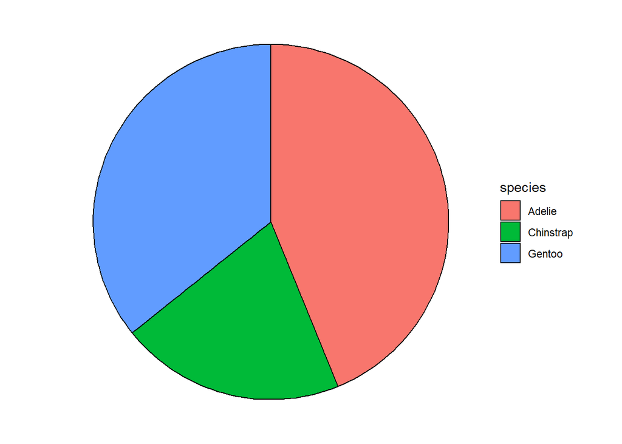

## 2.1 Adelie

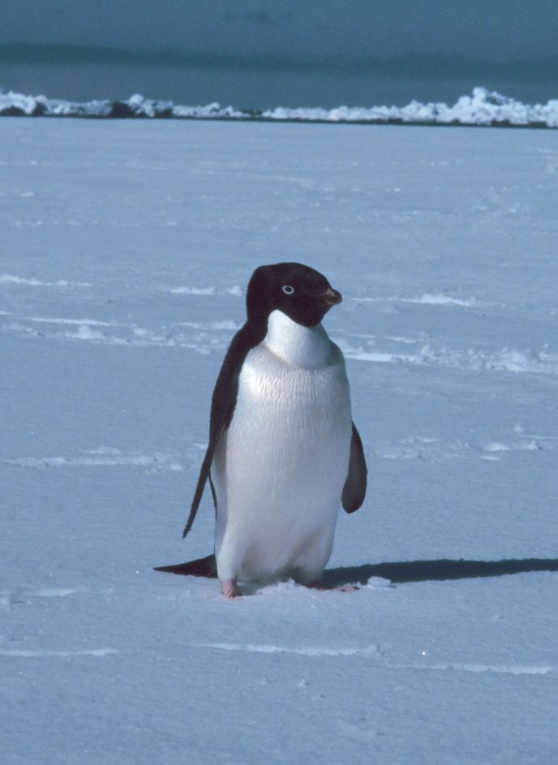

## 2.2 Chinstrap

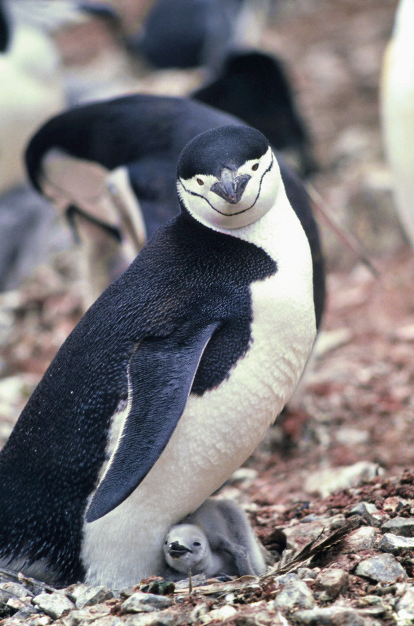

## 2.3 Gentoo

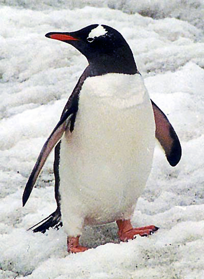

# 3 Features

Le variabili osservate sono la lunghezza e la profondità del becco, la lunghezza delle pinne, il sesso e il peso.

## 3.1 Bill length

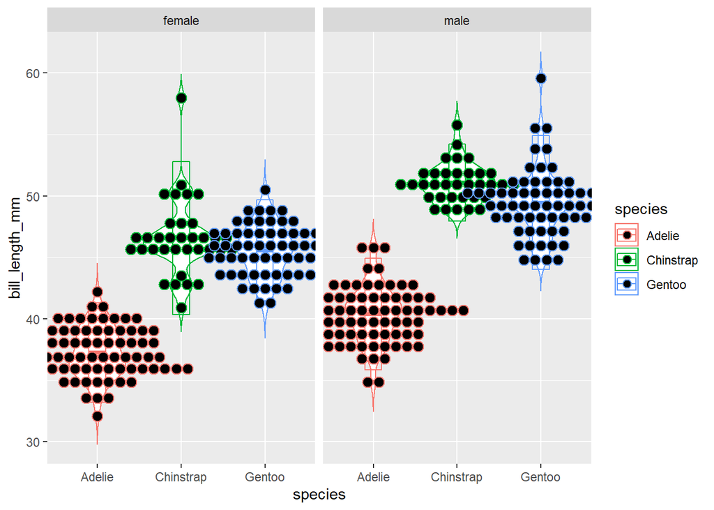

## 3.2 Bill depth

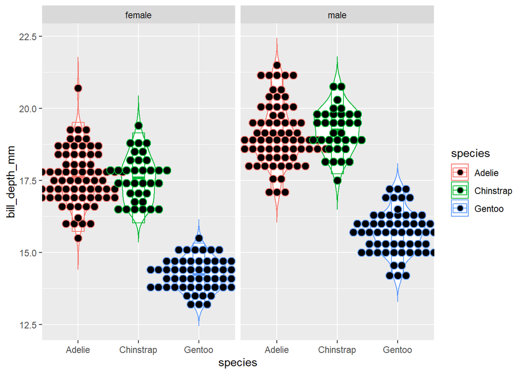

## 3.3 Flipper length

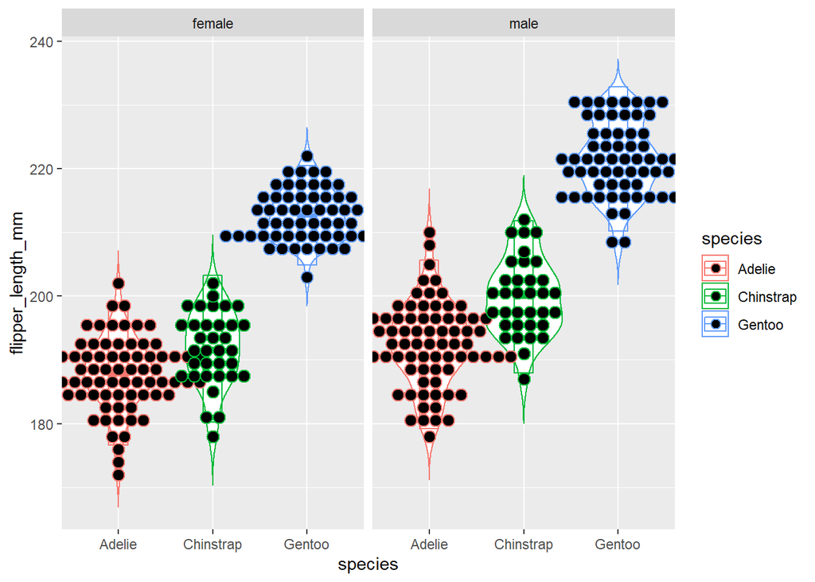

## 3.4 Body mass

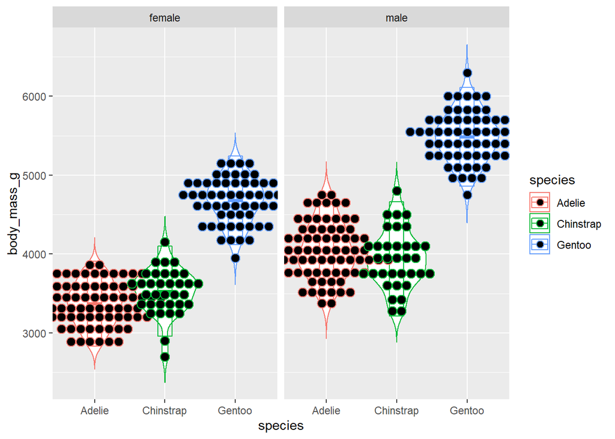

## 3.5 Flipper and bill length

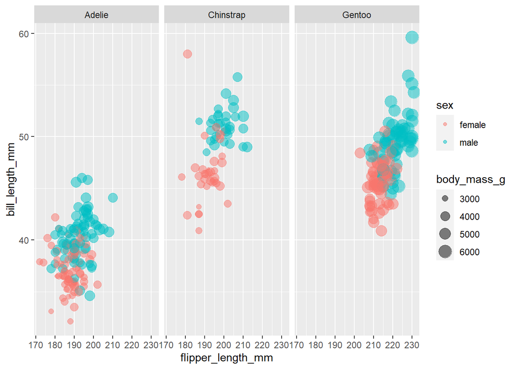

## 3.6 Flipper and bill depth

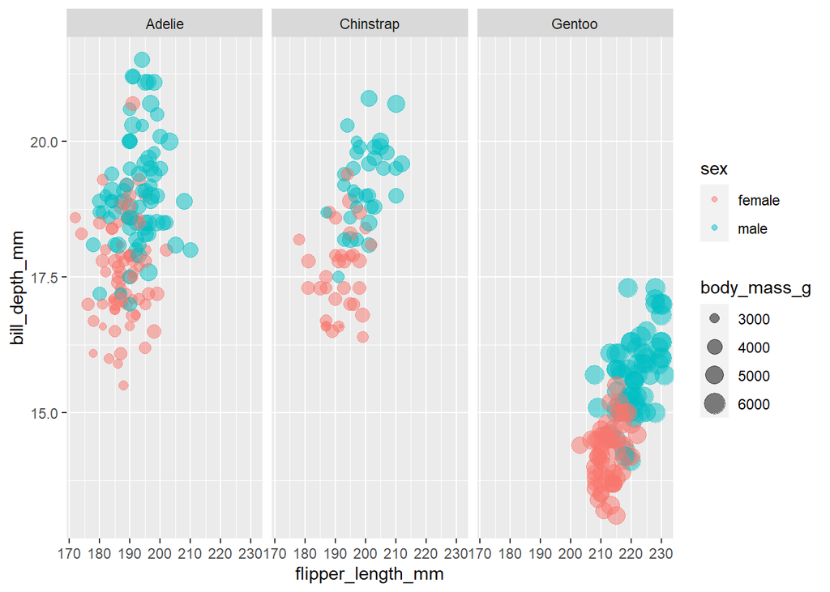

## 3.7 Bill length and bill depth

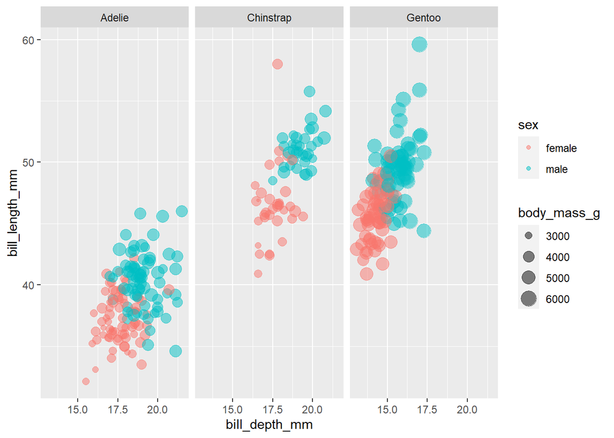

# 4 Splitting dataset

Il dataset è stato suddiviso in training e testing dataset (75/25) con il metodo stratificato utilizzando come variabile il sesso.  
Quindi, la proporzione dei sessi è uguale tra i due dataset ottenuti.  
Le righe contenenti NA sono state rimosse.  
Le colonne anno e isola sono state rimosse.

# 5 Modelling

25 bootstraps sono stati creati dal training dataset e su questi è allenato un modello di regressione logistica

# 6 Training performance

I risultati sono abbastanza soddisfacenti come risulta dalla matrice che riepiloga le metriche utilizzate nel fitting del modello sui vari training dataset.

| .metric | .estimator | mean | n | std_err | .config |
| --- | --- | --- | --- | --- | --- |
| accuracy | binary | 0.8969609 | 25 | 0.0063087 | Preprocessor1_Model1 |
| roc_auc | binary | 0.9638741 | 25 | 0.0036765 | Preprocessor1_Model1 |

# 7 ROC curve

Le curve di ROC dimostrano la bonta del fitting del modello di regressione logistica nel discriminare il sesso dei pinguini.

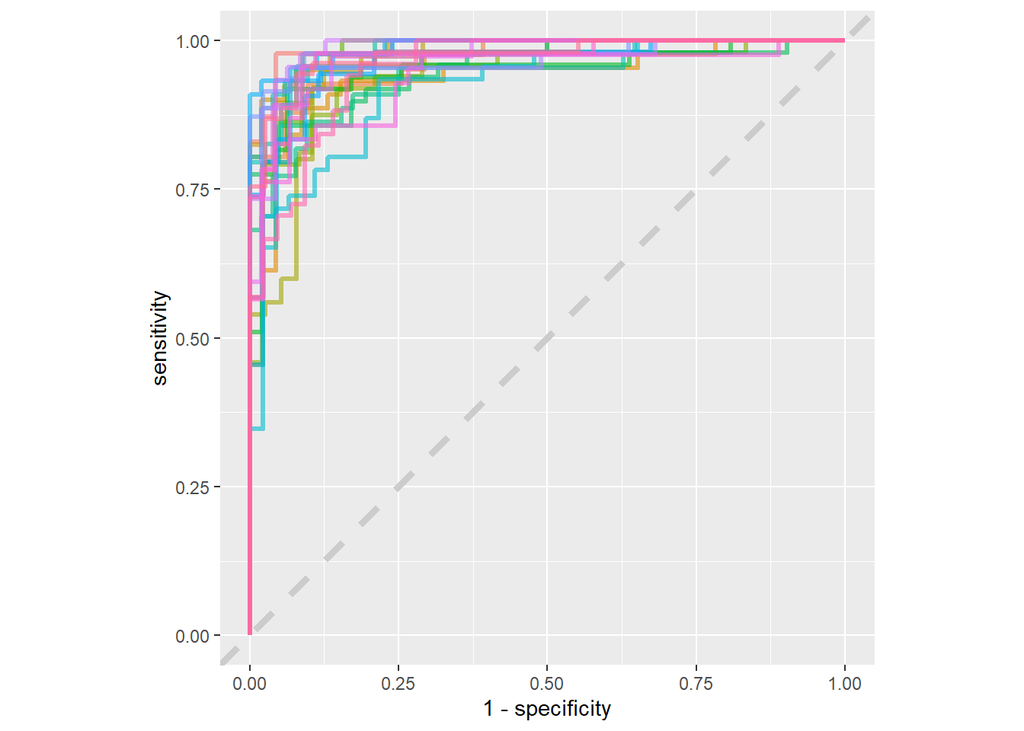

# 8 Evaluation on testing

Il modello è quindi valutato sul testing dataset e la performance è soddisfacente anche su nuovi dati mai visti dal modello.

| .metric | .estimator | .estimate | .config |
| --- | --- | --- | --- |
| accuracy | binary | 0.9397590 | Preprocessor1_Model1 |
| roc_auc | binary | 0.9912892 | Preprocessor1_Model1 |

La matrice di confusione che si ottine è la seguente

```
FALSE           Truth
FALSE Prediction female male
FALSE     female     39    3
FALSE     male        2   39
```

# 9 Model specification

| term | estimate | std.error | statistic | p.value |
| --- | --- | --- | --- | --- |
| (Intercept) | 0.00000 | 13.47213 | -5.89749 | 0.00000 |
| speciesChinstrap | 0.00134 | 1.70114 | -3.88852 | 0.00010 |
| speciesGentoo | 0.00011 | 2.89095 | -3.15797 | 0.00159 |
| bill_length_mm | 1.77887 | 0.13717 | 4.19892 | 0.00003 |
| bill_depth_mm | 3.89266 | 0.37341 | 3.63971 | 0.00027 |
| flipper_length_mm | 1.07321 | 0.05377 | 1.31393 | 0.18887 |
| body_mass_g | 1.00510 | 0.00108 | 4.69996 | 0.00000 |